# FIFA 2019 Player

4강가조

2019년 5월 17일

2018년 러시아 월드컵이 열리고 많은 사람들사이에서 이슈화가 되었습니다. 4년마다 열리는 월드컵에서 우리나라는 2002년 대한민국이 4강에 오른이후 더욱이 기대와 관심을 가지고있습니다. 그래서 주제를 찾던중에 축구선수와 관련된 주제를 찾게되어 우리가 축구경기를 볼때 축구선수들에대한 정보를 가지고 경기를 본다면 좀 더 재미있게 볼수있지 않을까 생각되어 주제를 정하게 되었습니다.

FIFA19(2018년 데이터에서 추출한 89가지 속성)들을 나타낸 데이터 입니다. 해당 데이터에서 개별 데이터와 연관 지을 수 있는 데이터들을 분석해보겠습니다.

[figure not shown]

```r
knitr::include_graphics("./pic.jpg", dpi = 84)
```

# 피파 19시즌 플레이어 데이터 불러오기

```r
fifa <- read.csv("data2.csv", header = T, stringsAsFactors = F, encoding = "CP949")
# 종합점수 상위 900개 데이터
fifa <- fifa[c(1:900),]
str(fifa)
```

```
## 'data.frame':    900 obs. of  89 variables:
##  $ X                       : int  0 1 2 3 4 5 6 7 8 9 ...
##  $ ID                      : int  158023 20801 190871 193080 192985 183277 177003 176580 155862 200389 ...
##  $ Name                    : chr  "L. Messi" "Cristiano Ronaldo" "Neymar Jr" "De Gea" ...
##  $ Age                     : int  31 33 26 27 27 27 32 31 32 25 ...
##  $ Photo                   : chr  "https://cdn.sofifa.org/players/4/19/158023.png" "https://cdn.sofifa.org/players/4/19/20801.png" "https://cdn.sofifa.org/players/4/19/190871.png" "https://cdn.sofifa.org/players/4/19/193080.png" ...
##  $ Nationality             : chr  "Argentina" "Portugal" "Brazil" "Spain" ...
##  $ Flag                    : chr  "https://cdn.sofifa.org/flags/52.png" "https://cdn.sofifa.org/flags/38.png" "https://cdn.sofifa.org/flags/54.png" "https://cdn.sofifa.org/flags/45.png" ...
##  $ Overall                 : int  94 94 92 91 91 91 91 91 91 90 ...
##  $ Potential               : int  94 94 93 93 92 91 91 91 91 93 ...
##  $ Club                    : chr  "FC Barcelona" "Juventus" "Paris Saint-Germain" "Manchester United" ...
##  $ Club.Logo               : chr  "https://cdn.sofifa.org/teams/2/light/241.png" "https://cdn.sofifa.org/teams/2/light/45.png" "https://cdn.sofifa.org/teams/2/light/73.png" "https://cdn.sofifa.org/teams/2/light/11.png" ...
##  $ Value                   : chr  "€110.5M" "€77M" "€118.5M" "€72M" ...
##  $ Wage                    : chr  "€565K" "€405K" "€290K" "€260K" ...
##  $ Special                 : int  2202 2228 2143 1471 2281 2142 2280 2346 2201 1331 ...
```

[output cut: 75 more lines]

# 선수가치 데이터 전처리

```r
library(ggplot2)
#선수들의 주급, 선수가치의 원화 환산값은 엄청 크기 때문에 지수 승이 아닌 정수로 모두 나타내 주기 위해 사용
options(scipen = 100)

#wage = 주급, value = 선수가치
head(fifa$Value)
```

```
## [1] "€110.5M" "€77M"    "€118.5M" "€72M"    "€102M"   "€93M"
```

```r
# 현재 선수가치변수에 문자열이 붙어있어 캐릭터형이기 때문에
# 유로(€) 문자를 제거해준다
fifa$Value <- substr(fifa$Value,2,10)

# 영어M 을제거해준다
fifa$Value <- gsub(x =fifa$Value, pattern = "[A-Z]",
               replacement = "")

# 모두 숫자이지만 아직 캐릭터형
str(fifa$Value)
```

```
##  chr [1:900] "110.5" "77" "118.5" "72" "102" "93" "67" "80" "51" "68" ...
```

```r
# 타입을 numeric으로 바꿔준다
fifa$Value <- as.numeric(fifa$Value)
str(fifa$Value)
```

```
##  num [1:900] 110 77 118 72 102 ...
```

```r
# 이제 numeric타입의 선수가치에 우리나라(원)으로 변경하는 과정
# M 은 0을 6추가 해줘야한다 (10^6 을 곱해준다 )
for(i in 1 : nrow(fifa)){
  fifa$Value[i] <- fifa$Value[i] * 1000000
}
# 현재 유로화 가치 1유로당 1,335원을 적용 시켜 원화로 만들어준다
for(i in 1 : nrow(fifa)){
  fifa$Value[i] <- fifa$Value[i] * 1335
}

head(fifa$Value)
```

```
## [1] 147517500000 102795000000 158197500000  96120000000 136170000000
## [6] 124155000000
```

# 마찬가지로 주급도 같은과정을 통해 전처리

```r
head(fifa$Wage)
```

```
## [1] "€565K" "€405K" "€290K" "€260K" "€355K" "€340K"
```

```r
fifa$Wage <- substr(fifa$Wage,2,10)
fifa$Wage <- gsub(x =fifa$Wage, pattern = "[A-Z]",
               replacement = "")
str(fifa$Wage)
```

```
##  chr [1:900] "565" "405" "290" "260" "355" "340" "420" "455" "380" ...
```

```r
fifa$Wage <- as.numeric(fifa$Wage)
str(fifa$Wage)
```

```
##  num [1:900] 565 405 290 260 355 340 420 455 380 94 ...
```

```r
# 이제 numeric타입의 선수가치에 우리나라(원)으로 변경하는 과정
# K 는 0을 3개 추가 해줘야한다 (10^3 을 곱해준다 )
for(i in 1 : nrow(fifa)){
  fifa$Wage[i] <- fifa$Wage[i] * 1000
}
# 현재 유로화 가치 1유로당 1,335원을 적용 시켜 원화로 만들어준다
for(i in 1 : nrow(fifa)){
  fifa$Wage[i] <- fifa$Wage[i] * 1335
}

head(fifa$Wage)
```

```
## [1] 754275000 540675000 387150000 347100000 473925000 453900000
```

# 선수의 몸무게(파운드)를 kg단위로 변경

```r
head(fifa$Weight)
```

```
## [1] "159lbs" "183lbs" "150lbs" "168lbs" "154lbs" "163lbs"
```

```r
fifa$Weight <- gsub(x =fifa$Weight, pattern = "[a-z]",
               replacement = "")

str(fifa$Weight)
```

```
##  chr [1:900] "159" "183" "150" "168" "154" "163" "146" "190" "181" ...
```

```r
fifa$Weight <- as.numeric(fifa$Weight)
str(fifa$Weight)
```

```
##  num [1:900] 159 183 150 168 154 163 146 190 181 192 ...
```

```r
# 파운드를 kg으로 변경하는 공식 파운드 / 2.205
for(i in 1 : nrow(fifa)){
  fifa$Weight[i] <- round(fifa$Weight[i] / 2.205,2)
}

head(fifa$Weight)
```

```
## [1] 72.11 82.99 68.03 76.19 69.84 73.92
```

# 선수의 키(피트인치)를 cm로 변경

```r
head(fifa$Height)
```

```
## [1] "5'7"  "6'2"  "5'9"  "6'4"  "5'11" "5'8"
```

```r
head(strsplit(fifa$Height,"'"))
```

```
## [[1]]
## [1] "5" "7"
##
## [[2]]
## [1] "6" "2"
##
## [[3]]
## [1] "5" "9"
##
## [[4]]
## [1] "6" "4"
##
## [[5]]
## [1] "5"  "11"
##
## [[6]]
## [1] "5" "8"
```

```r
fifa$Height <- strsplit(fifa$Height,"'")


heightSum <- c()

# 앞자리는 피트 , 뒷자리는 인치 이기 때문에
# 앞자리에는 * 30.48, 뒷자리에는 * 2.54를 하고 더해주면 cm로 변환 가능
for(i in 1 : nrow(fifa)){
  heightSum[i] <- (as.numeric(fifa$Height[[i]][1])*30.48) + (as.numeric(fifa$Height[[i]][2])*2.54)
}

fifa$Height <- heightSum

head(fifa$Height)
```

```
## [1] 170.18 187.96 175.26 193.04 180.34 172.72
```

# 선수가치가 높은 상위 10명의 선수

```r
library(knitr)
head(order(fifa$Value, decreasing =  T), 10)
```

```
##  [1]  3  1  5  6 16 17 26  8 18  2
```

```r
#선수가치가 높은 상위 10명의 선수 이름
fifa[head(order(fifa$Value, decreasing =  T), 10),]$Name
```

```
##  [1] "Neymar Jr"         "L. Messi"          "K. De Bruyne"
##  [4] "E. Hazard"         "P. Dybala"         "H. Kane"
##  [7] "K. Mbappe"         "L. Suarez"         "A. Griezmann"
## [10] "Cristiano Ronaldo"
```

```r
#선수가치가 높은 상위 10명의 선수 가치
fifa[head(order(fifa$Value, decreasing =  T), 10),]$Value
```

```
##  [1] 158197500000 147517500000 136170000000 124155000000 118815000000
##  [6] 111472500000 108135000000 106800000000 104130000000 102795000000
```

```r
fifa10 <- data.frame(Name = fifa[head(order(fifa$Value, decreasing =  T), 10),]$Name, Value = fifa[head(order(fifa$Value, decreasing =  T), 10),]$Value)

names(fifa10) <- c("Name", "Value(단위 :원)")

fifa10
```

```
##                 Name Value(단위 :원)
## 1          Neymar Jr    158197500000
## 2           L. Messi    147517500000
## 3       K. De Bruyne    136170000000
## 4          E. Hazard    124155000000
## 5          P. Dybala    118815000000
## 6            H. Kane    111472500000
## 7          K. Mbappe    108135000000
## 8          L. Suarez    106800000000
## 9       A. Griezmann    104130000000
## 10 Cristiano Ronaldo    102795000000
```

# 선수가치가 높은 선수들 100명의 국적 분포

```r
library(knitr)
head(order(fifa$Value, decreasing = T),100)
```

```
##   [1]   3   1   5   6  16  17  26   8  18   2  11  12  31  32   4  27  29
##  [18]  33  10   7  24  44  46  15  48  30  56  14  22  37  28  57  34  19
##  [35]  39  43  61  64  80  20  62  49  59  21   9  45  79  84  63  81  53
##  [52]  54  66  78  35  68  51  67  87  88  60  13  73  69  75  36 117 118
##  [69] 125  58 157  83  85 115 156  72  95 123 101  23  50  86 122  89  94
##  [86]  98  91  92 106 126  65  82 116 167  38 102 120 164  70 177
```

```r
ValueOf <- fifa[head(order(fifa$Value, decreasing = T),100),]
national_tbl <-table(ValueOf$Nationality)
national_df <- data.frame(national_tbl)
names(national_df) <- c("국적", "선수의 수")
national_df$`선수의 수` <- sort(national_df$`선수의 수`, decreasing = T)
kable(national_df)
```

| 국적 | 선수의 수 |
| --- | --- |
| Algeria | 14 |
| Argentina | 13 |
| Austria | 13 |
| Belgium | 10 |
| Bosnia Herzegovina | 7 |
| Brazil | 5 |
| Chile | 4 |
| Colombia | 4 |
| Croatia | 3 |
| Denmark | 3 |
| Egypt | 3 |
| England | 2 |
| France | 2 |
| Gabon | 2 |
| Germany | 2 |
| Greece | 1 |
| Italy | 1 |
| Korea Republic | 1 |
| Netherlands | 1 |
| Poland | 1 |
| Portugal | 1 |
| Senegal | 1 |
| Serbia | 1 |
| Slovakia | 1 |
| Slovenia | 1 |
| Spain | 1 |
| Uruguay | 1 |
| Wales | 1 |

```r
print(" ") #kable출력오류때문에 사용
```

```
## [1] " "
```

# 선수가치가 높은 선수들 100명의 구단 분포

```r
library(knitr)
head(order(fifa$Value, decreasing = T),100)
```

```
##   [1]   3   1   5   6  16  17  26   8  18   2  11  12  31  32   4  27  29
##  [18]  33  10   7  24  44  46  15  48  30  56  14  22  37  28  57  34  19
##  [35]  39  43  61  64  80  20  62  49  59  21   9  45  79  84  63  81  53
##  [52]  54  66  78  35  68  51  67  87  88  60  13  73  69  75  36 117 118
##  [69] 125  58 157  83  85 115 156  72  95 123 101  23  50  86 122  89  94
##  [86]  98  91  92 106 126  65  82 116 167  38 102 120 164  70 177
```

```r
ValueOf <- fifa[head(order(fifa$Value, decreasing = T),100),]
Club_tbl <-table(ValueOf$Club)
Club_df <- data.frame(Club_tbl)
names(Club_df) <- c("구단", "선수의 수")
Club_df$`선수의 수` <- sort(Club_df$`선수의 수`, decreasing = T)
kable(Club_df)
```

| 구단 | 선수의 수 |
| --- | --- |
| Arsenal | 11 |
| Atletico Madrid | 9 |
| Borussia Dortmund | 9 |
| Chelsea | 9 |
| FC Barcelona | 7 |
| FC Bayern Munchen | 6 |
| FC Porto | 5 |
| Guangzhou Evergrande Taobao FC | 5 |
| Inter | 5 |
| Juventus | 5 |
| Lazio | 5 |
| Liverpool | 4 |
| Manchester City | 4 |
| Manchester United | 3 |
| Milan | 2 |
| Napoli | 2 |
| Olympique de Marseille | 2 |
| Olympique Lyonnais | 1 |
| Paris Saint-Germain | 1 |
| Real Madrid | 1 |
| Roma | 1 |
| Sporting CP | 1 |
| Tottenham Hotspur | 1 |
| Valencia CF | 1 |

```r
print(" ") #kable출력오류때문에 사용
```

```
## [1] " "
```

# 선수들이 선호하는 발의 방향

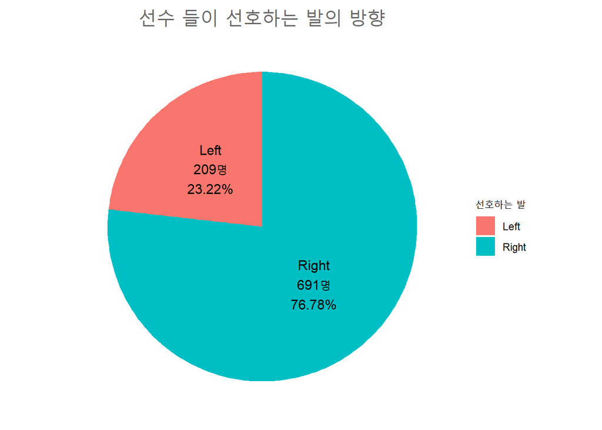

```r
preferFoot <- data.frame(table(fifa$Preferred.Foot))
colnames(preferFoot) <- c("선호하는 발", "선호하는 선수의 수")

footPct <- round(preferFoot$`선호하는 선수의 수`/sum(preferFoot$`선호하는 선수의 수`) * 100,2)

footPct <- paste0(preferFoot$`선호하는 발`,"\n",preferFoot$`선호하는 선수의 수`,"명\n",footPct,"%")



ggplot(preferFoot,aes("",preferFoot$`선호하는 선수의 수`,fill = preferFoot$`선호하는 발`)) + geom_bar(stat = "identity") + coord_polar("y", start=0) +
  geom_text(aes(label =footPct), position = position_stack(vjust = 0.5), cex = 4) +
  theme_classic() + theme(axis.line = element_blank(),
          axis.text = element_blank(),
          axis.ticks = element_blank(),
          plot.title = element_text(hjust = 0.5, color = "#666666", size = 20)) +
  labs(x = NULL, y = NULL, fill = "선호하는 발 ", title = "선수 들이 선호하는 발의 방향")
```

# 포지션별 선수가치 상자그림

ST: 스트라이커 GK : 골키퍼 (goalkeeper) 공이 골에 들어가는 것을 막는 역할을 하는 포지션. 공을 손으로 만지는 것이 허용되는 유일한 선수이다. CB : 중앙수비수, 센터백 CM : 중앙미드필더 LB : 레프트백 (left back) 필드의 왼쪽을 담당하는 수비 포지션. 주요 역할은 상대 팀이 골을 향해 가는 것을 지연시키거나 막는 것이다. RB : 라이트백 RM : [RM] Right Midfielder 오른쪽 측면 미드필더 LM : [LM] Left Midfielder 왼쪽 측면 미드필더, 레프트 미드필더 (left midfielder) 필드의 왼쪽에서 경기하는 중앙 포지션. 공을 공격수에게 패스하는 경기 운영 기술을 사용한다. CAM : 공격형미드필더 ,센터 어태킹 미드필더 (Center atacking midfielder) CDM : 중앙 수비형 미드필더입니다 RCB : [RCB] Right Center Back 오른쪽 중앙 수비수 LCB : [LCB] Left Center Back 왼쪽 중앙 수비수 LCM : [LCM] Left Center Midfielder 왼쪽 중앙 미드필더 RCM : [RCM] Right Center Midfielder 오른쪽 중앙 미드필더 LW : 왼쪽윙어 RW : 오른쪽윙어  
RDM : 오른쪽 수비형미드필더 LDM : 왼쪽 수비형 미드필더 LS : [LS] Left Striker 왼쪽 스트라이커 RS : [RS] Right Striker 오른쪽 스트라이커 RWB : [RWB] Right Wing Back 오른쪽 윙백 LWB : [LWB] Left Wing Back 왼쪽 윙백 CF : 중앙공격수 LAM : [LAM] Left Attacking Midfielder 왼쪽 공격형 미드필더 RAM : [RAM]Right Attacking Midfielder 오른쪽 공격형 미드필더 RF : 오른쪽 공격수 LF : 왼쪽공격수

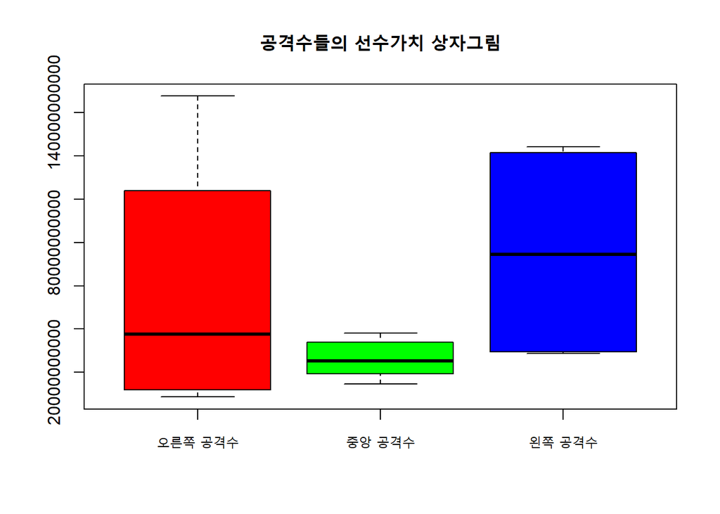

```r
value_position <- split(fifa$Value, fifa$Position)
boxplot(value_position$RF,value_position$CF,value_position$LF, names = c("오른쪽 공격수", "중앙 공격수", "왼쪽 공격수"), main = "공격수들의 선수가치 상자그림", col = rainbow(3))
```

```r
median(value_position$RF) # 오른쪽 공격수의 선수가치 중앙값
```

```
## [1] 37713750000
```

```r
median(value_position$CF) # 중앙 공격수의 선수가치 중앙값
```

```
## [1] 25365000000
```

```r
median(value_position$LF) # 왼쪽 공격수의 선수가치 중앙값
```

```
## [1] 74426250000
```

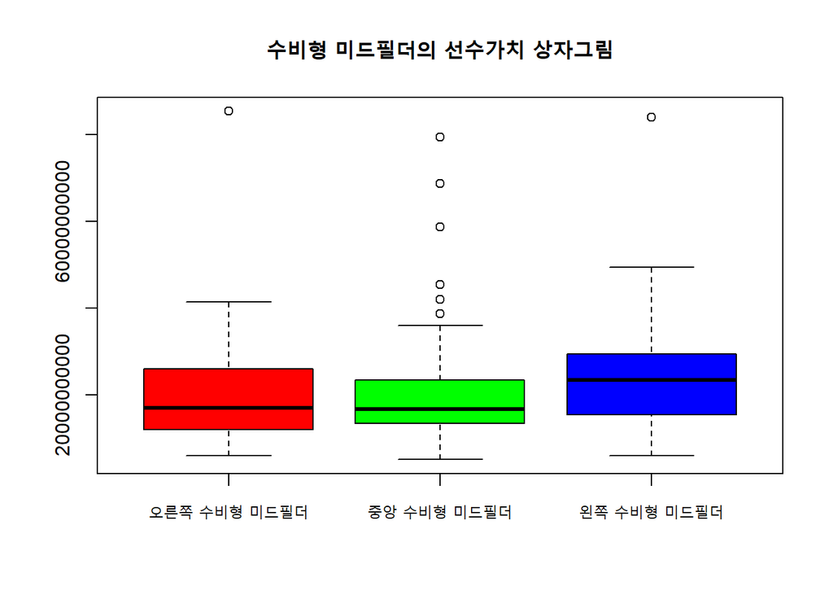

```r
boxplot(value_position$RDM,value_position$CDM,value_position$LDM, names = c("오른쪽 수비형 미드필더", "중앙 수비형 미드필더","왼쪽 수비형 미드필더"),main = "수비형 미드필더의 선수가치 상자그림",
col = rainbow(3))
```

```r
median(value_position$RDM) # 오른쪽 수비미 미드필더의 선수가치 중앙값
```

```
## [1] 17021250000
```

```r
median(value_position$CDM) # 중앙 수비형 미드필더의 선수가치 중앙값
```

```
## [1] 16687500000
```

```r
median(value_position$LDM) # 왼쪽 수비형 미드필더의 선수가치 중앙값
```

```
## [1] 23362500000
```

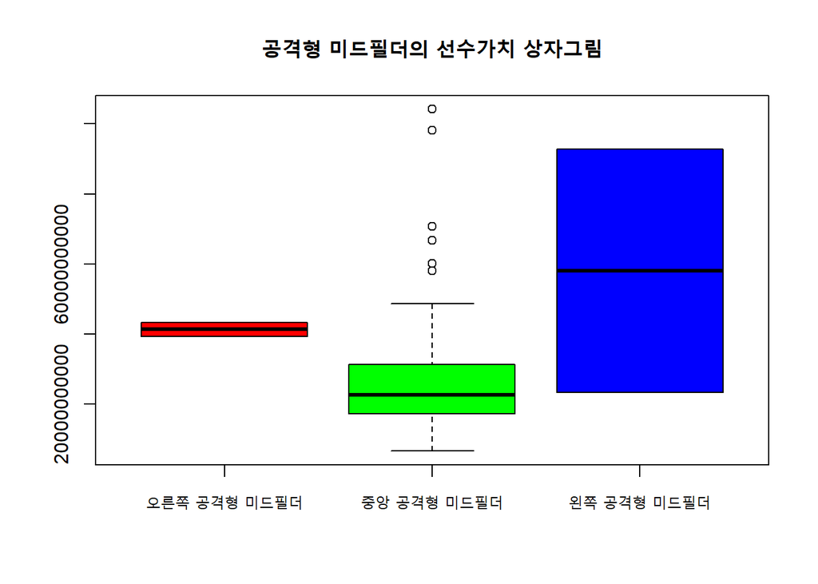

```r
boxplot(value_position$RAM,value_position$CAM,value_position$LAM, names = c("오른쪽 공격형 미드필더", "중앙 공격형 미드필더","왼쪽 공격형 미드필더"),main = "공격형 미드필더의 선수가치 상자그림", col = rainbow(3))
```

```r
median(value_position$RAM) # 오른쪽 공격형 미드필더의 선수가치 중앙값
```

```
## [1] 41385000000
```

```r
median(value_position$CAM) # 중앙 공격형 미드필더의 선수가치 중앙값
```

```
## [1] 22695000000
```

```r
median(value_position$LAM) # 왼쪽 공격형 미드필더의 선수가치 중앙값
```

```
## [1] 58072500000
```

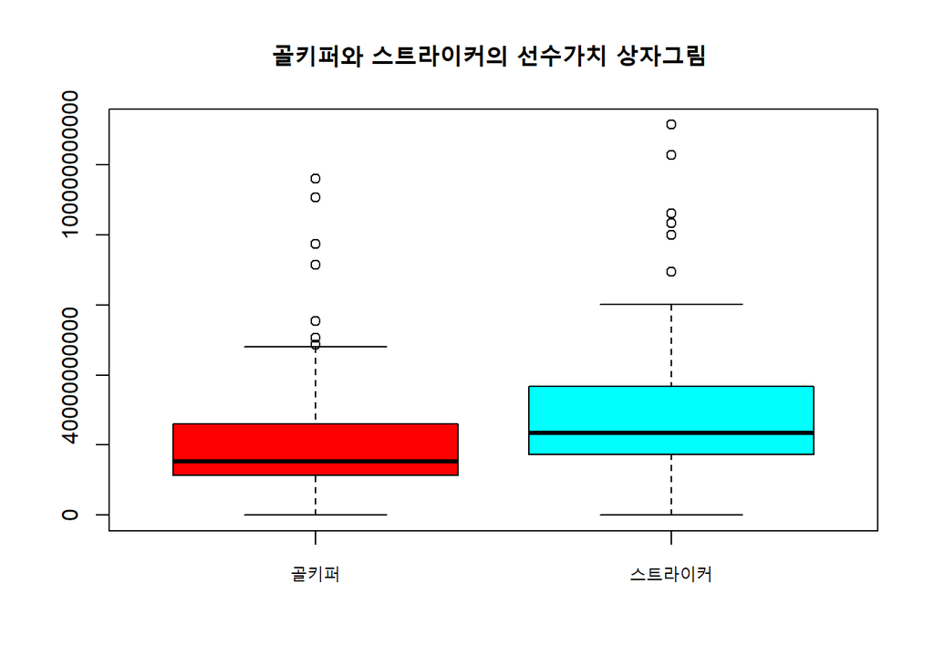

```r
boxplot(value_position$GK, value_position$ST, names = c("골키퍼", "스트라이커"), main = "골키퍼와 스트라이커의 선수가치 상자그림 ", col = rainbow(2))
```

```r
median(value_position$GK) # 골키퍼의 선수가치 중앙값
```

```
## [1] 15352500000
```

```r
median(value_position$ST) # 스트라이커의 선수가치 중앙값
```

```
## [1] 23362500000
```

# 종합점수 상위 900명의 포지션별 선수의 분포 트리맵

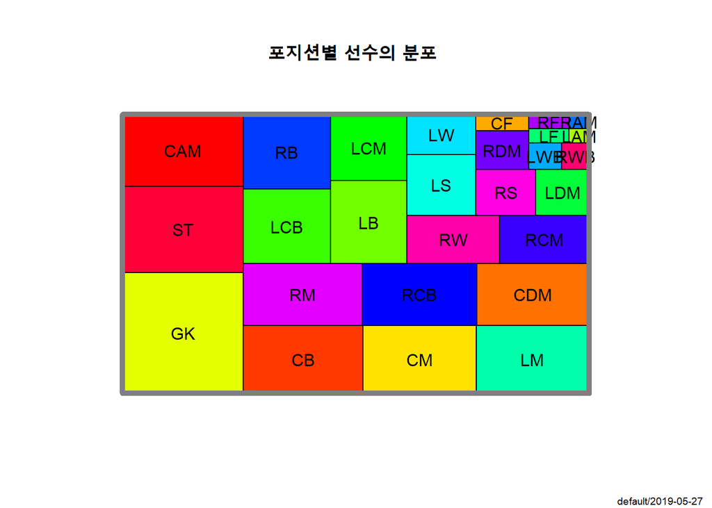

```r
library(DescTools)
a <- data.frame(table(fifa$Position))
colnames(a) <- c("position", "선수 수")
PlotTreemap(x=a$`선수 수`, labels= a$position, main = "포지션별 선수의 분포 ")
```

# 선수들의 키 분포

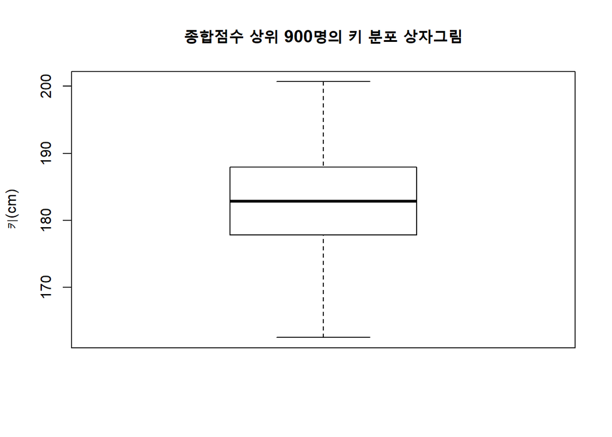

```r
boxplot(fifa$Height, main = "종합점수 상위 900명의 키 분포 상자그림", ylab = "키(cm)")
```

```r
#선수들의 키 최대값
max(fifa$Height)
```

```
## [1] 200.66
```

```r
#선수들의 키 최소값
min(fifa$Height)
```

```
## [1] 162.56
```

```r
#선수들의 키 중앙값
median(fifa$Height)
```

```
## [1] 182.88
```

# 선수들의 몸무게 분포

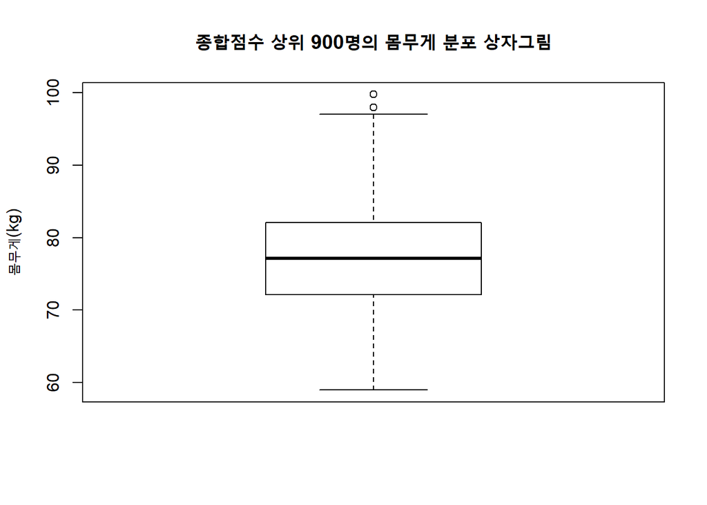

```r
boxplot(fifa$Weight,  main = "종합점수 상위 900명의 몸무게 분포 상자그림", ylab = "몸무게(kg)")
```

```r
#선수들의 몸무게 최대값
max(fifa$Weight)
```

```
## [1] 99.77
```

```r
#선수들의 몸무게 최소값
min(fifa$Weight)
```

```
## [1] 58.96
```

```r
#선수들의 몸무게 중앙값
median(fifa$Weight)
```

```
## [1] 77.1
```

# 키, 몸무게에 따른 점프력 산점도

```r
cor(fifa$Weight,fifa$Jumping)
```

```
## [1] 0.1508761
```

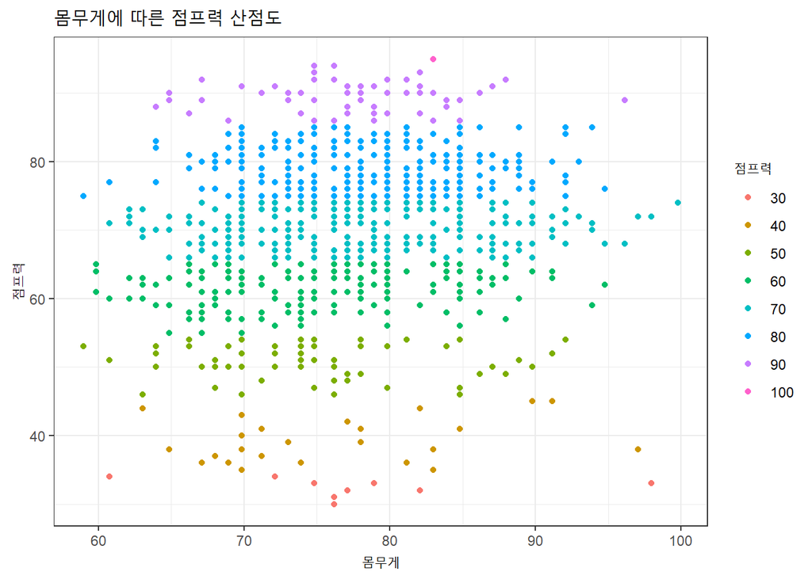

```r
ggplot(fifa,aes(fifa$Weight,fifa$Jumping,colour = factor(round(fifa$Jumping,-1)))) + geom_point() + labs(x ="몸무게" ,y = "점프력", colour = "점프력", title = "몸무게에 따른 점프력 산점도")  + theme_bw()
```

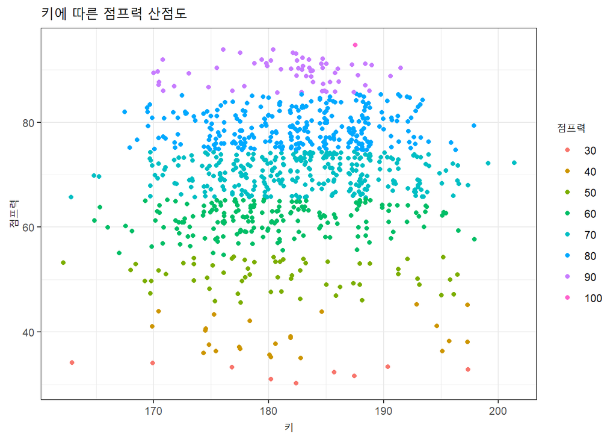

```r
ggplot(fifa,aes(fifa$Height,fifa$Jumping,colour = factor(round(fifa$Jumping,-1)))) + geom_jitter() + labs(x ="키" ,y = "점프력", colour = "점프력", title = "키에 따른 점프력 산점도") + theme_bw()
```

# 선수들의 나이 분포

```r
library(knitr)

kable(table(fifa$Age))
```

| Var1 | Freq |
| --- | --- |
| 18 | 1 |
| 19 | 7 |
| 20 | 10 |
| 21 | 31 |
| 22 | 46 |
| 23 | 56 |
| 24 | 72 |
| 25 | 87 |
| 26 | 91 |
| 27 | 85 |
| 28 | 82 |
| 29 | 76 |
| 30 | 67 |
| 31 | 69 |
| 32 | 48 |
| 33 | 28 |
| 34 | 23 |
| 35 | 8 |
| 36 | 6 |
| 37 | 4 |
| 39 | 1 |
| 40 | 2 |

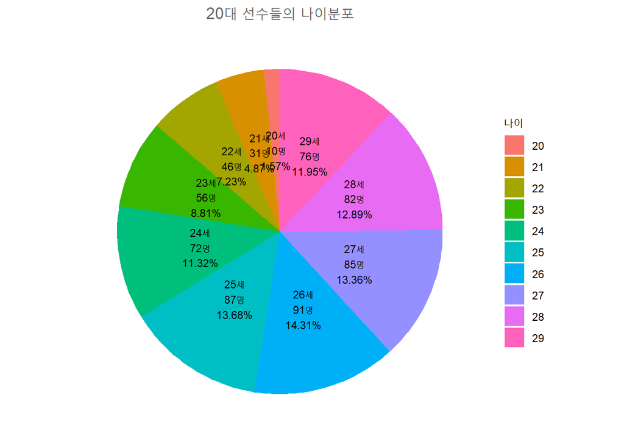

```r
AgeCount <- data.frame(age = table(fifa$Age)[3:12])
agePct <- round(table(fifa$Age)[3:12]/sum(table(fifa$Age)[3:12]) * 100,2)
agePct <- paste0(names(table(fifa$Age)[3:12]),"세\n",table(fifa$Age)[3:12],"명\n",agePct,"%")

#20대 선수들의 분포

ggplot(AgeCount,aes("",age.Freq,fill = AgeCount$age.Var1)) + geom_bar(stat = "identity") + coord_polar("y", start=0) +
  geom_text(aes(label =agePct), position = position_stack(vjust = 0.5), cex = 3) +
  theme_classic() + theme(axis.line = element_blank(),
          axis.text = element_blank(),
          axis.ticks = element_blank(),
          plot.title = element_text(hjust = 0.5, color = "#666666")) +
  labs(x = NULL, y = NULL, fill = "나이", title = "20대 선수들의 나이분포")
```

```r
# 전체 데이터 중 20대 선수의 비중
sum(table(fifa$Age)[3:12])/sum(table(fifa$Age)) * 100
```

```
## [1] 70.66667
```

# 나이와 선수가치의 관계

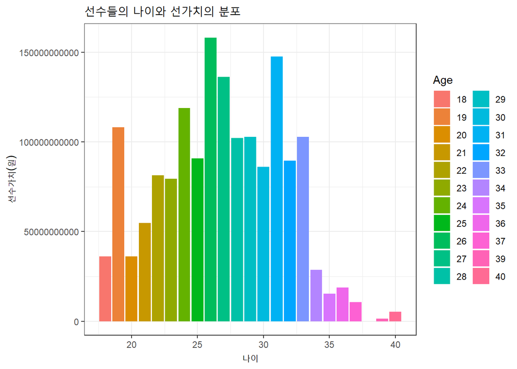

```r
ggplot(fifa,aes(fifa$Age,fifa$Value,fill = factor(fifa$Age))) + geom_bar(stat = "identity" ,position = position_dodge()) + labs(x ="나이" ,y = "선수가치(원)", fill = "Age", title = "선수들의 나이와 선가치의 분포")  + theme_bw()
```

# 키와 몸무게별 구단 비교

```r
#축구 클럽 별 평균키가 큰 클럽들을 추출
clubHeight <- aggregate(fifa[27], list(Club = fifa$Club), mean)

#평균키가 큰 상위 10개의 구단
topHeight <- head(clubHeight[order(clubHeight$Height,decreasing = T),],10)
topHeight
```

```
##                          Club   Height
## 135                Stoke City 195.5800
## 55                  Frosinone 193.0400
## 2                  1. FC K?ln 189.2300
## 147             VfL Wolfsburg 188.3229
## 8   America FC (Minas Gerais) 187.9600
## 32      Club Atletico Hurac?n 187.9600
## 46   FC Girondins de Bordeaux 187.9600
## 66                Hannover 96 187.9600
## 69          Huddersfield Town 187.9600
## 98                       PAOK 187.9600
```

```r
#축구 클럽 별 평균 몸무게가 큰 클럽들을 추출
clubWeight <- aggregate(fifa[28], list(Club = fifa$Club), mean)

#평균 몸무게가 큰 상위 10개의 구단
topWeight <- head(clubWeight[order(clubWeight$Weight,decreasing = T),],10)
topWeight
```

```
##                          Club Weight
## 135                Stoke City 94.780
## 8   America FC (Minas Gerais) 87.980
## 46   FC Girondins de Bordeaux 87.980
## 55                  Frosinone 87.070
## 65               Hamburger SV 87.070
## 41        Eintracht Frankfurt 85.260
## 25     Brighton & Hove Albion 85.035
## 28                 CD Tondela 84.810
## 98                       PAOK 84.810
## 105                 Queretaro 84.810
```

```r
# 키가 큰 선수들이 모인 구단과 몸무게가 많이 나가는 구단이 겹칠 수 있는지 확인
for(i in 1 : 10){
  if(topHeight$Club[i] %in% topWeight$Club[i] | topWeight$Club[i] %in% topHeight$Club[i]){
    print(topHeight$Club[i])
  }
}
```

```
## [1] "Stoke City"
```

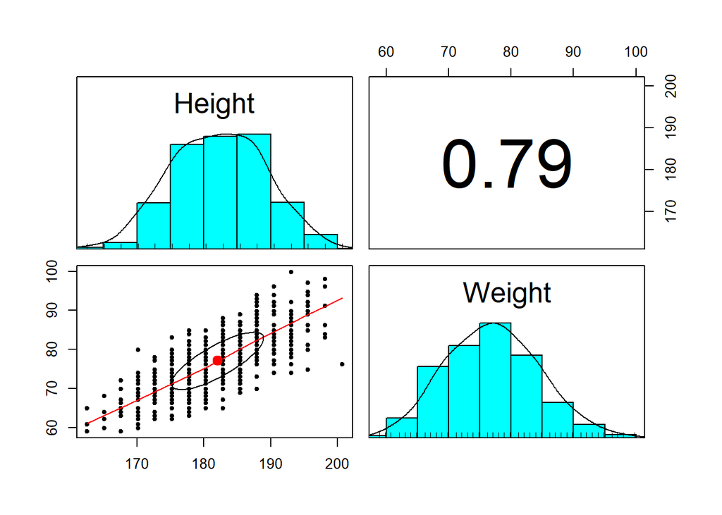

```r
#전체 데이터의 키와 몸무게에 대한 다중회귀분석 산점도 행렬 (전체적으로 봤을 때는 키가 클수록 몸무게도 큰편

library(psych)

pairs.panels(fifa[c(27,28)])
```

# 키가 크면 헤딩 정확성이 좋을지 알아보기

```r
#데이터에서 키가 큰 순서로 100명을 뽑는다
head(order(fifa$Height, decreasing = T),100)
```

```
##   [1] 464  20 103 211 280 468 705 763  93 110 116 166 205 226 230 262 275
##  [18] 288 304 311 318 373 467 545 635 640 719 768 875 883   4  23  41  42
##  [35]  46  55  60  96  99 133 134 169 190 192 216 260 295 302 305 309 310
##  [52] 339 374 378 469 484 510 513 527 535 539 549 572 610 620 644 667 673
##  [69] 701 704 725 735 761 780 782 813 843 882  35  48  63  71  79  82 108
##  [86] 132 140 151 167 176 197 202 203 213 214 223 228 233 246 258
```

```r
heightOfheading <- fifa[head(order(fifa$Height, decreasing = T),100),]

#뽑은 100명의 headingAccuracy 확인
#키가 큰 다수의 선수들의 headingAccuracy가 10점대가 많은 것을 알 수 있음
heightOfheading$HeadingAccuracy
```

```
##   [1] 11 13 94 15 14 87 12 84 16 83 86 80 94 14 12 88 80 79 89 13 19 14 12
##  [24] 10 15 73 10 86 86 13 21 25 10 13 73 83 82 85 84 74 11 77 14 80 87 87
##  [47] 74 83 90 85 11 11 79 82 80 82  8 23 12 85 81 13 20 11 82 71 18 85 93
##  [70] 16 92 13 24 18 79 84 76 78 87 86 83 86 86 19 84 13 90 77 77 81 14 13
##  [93] 85 23 11 16 75 11 80 80
```

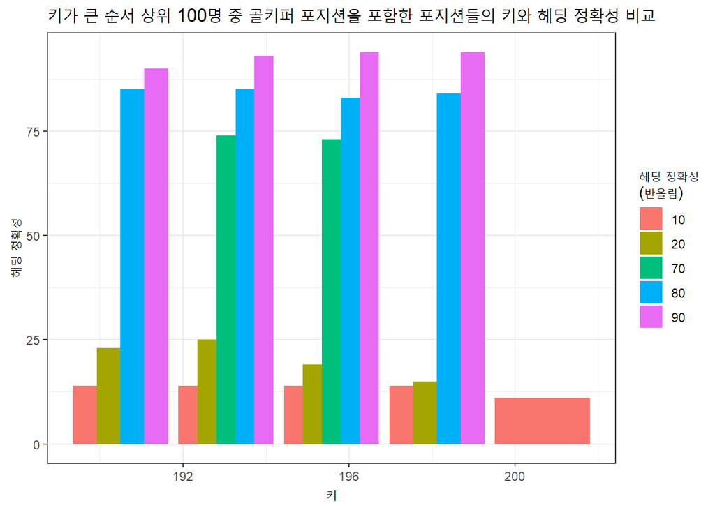

```r
#키가 큰 순서 상위 100명 중 골키퍼 포지션을 포함한 포지션들의 키와 헤딩 정확성 비교
ggplot(heightOfheading,aes(heightOfheading$Height,heightOfheading$HeadingAccuracy,fill = factor(round(heightOfheading$HeadingAccuracy,-1)))) + geom_bar(stat = "identity",position = position_dodge()) + labs(x ="키" ,y = "헤딩 정확성", fill = "헤딩 정확성\n(반올림)", title = "키가 큰 순서 상위 100명 중 골키퍼 포지션을 포함한 포지션들의 키와 헤딩 정확성 비교") + theme_bw()
```